# Spatial Regression Exercise

Sarah Krueger

11/8/2021

# 1 Dataset and Study Summary

In this exercise, I examined the effect of numerous socioeconomic factors related to percentage of children under the age of 18 who are living below the poverty line in the Southern United States.

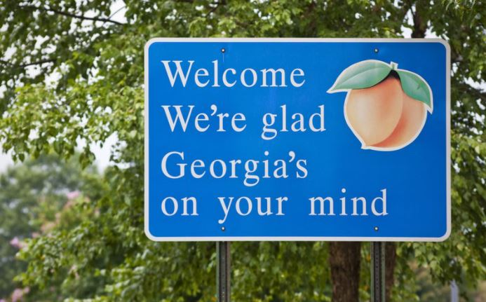

I began by reading in data provided by the U.S. Census Bureau, American Community Survey, Bureau of Labor Force Statistics, U.S. Department of Agriculture Economic Research Service, and the County Health Rankings.

Independent variables include: rural, urban, manufacturing, agriculture, retail, health care, construction, less than high school degree, unemployment, income ratio, teen birth, unmarried, single mother household, uninsured, as well as race variable like Black and Hispanic.

```r
data <- read.csv('./childpov18_southfull.csv',
                   colClasses = c("character", "character", "character",
                                  "numeric", "numeric", "numeric", "numeric",
                                  "numeric", "numeric", "numeric", "numeric",
                                  "numeric", "numeric", "numeric", "numeric",
                                  "numeric", "numeric", "numeric", "numeric",
                                  "numeric", "numeric", "numeric", "numeric",
                                  "numeric", "numeric", "numeric", "numeric",
                                  "numeric", "numeric", "numeric", "numeric",
                                  "numeric", "numeric", "numeric", "numeric"))

names(data)[names(data)=="X2016.child.poverty"] <- "child.pov.2016"

head(data)
```

|  | FIPS | State | County_Name | Longitude | Latitude | child.pov.2016 | unemployment_13 | per_lhs_13 | per_black_13 | per_hispanic_13 | per_ag_13 | per_construction_13 | per_manufacturing_13 | per_retail_13 | per_healthss_13 | per_singlemom_13 | urban | rural | lnchildpov | lnunemployment | lnlesshs | lnblack | lnhispanic | lnag | lnconstruction | lnmanufacturing | lnretail | lnhealthss | lnsinglemom | … |
| --- | --- | --- | --- | --- | --- | --- | --- | --- | --- | --- | --- | --- | --- | --- | --- | --- | --- | --- | --- | --- | --- | --- | --- | --- | --- | --- | --- | --- | --- | --- |
| 1 | 1001 | AL | Autauga County | -86.64130 | 32.53942 | 16.7 | 6.2 | 14.4 | 18.216257 | 2.486022 | 1.403685 | 5.802732 | 12.883820 | 13.527176 | 17.70899 | 11.703934 | 1 | 0 | 2.815409 | 1.824549 | 2.667228 | 2.902314 | 0.9106838 | 0.3391007 | 1.758329 | 2.555972 | 2.604701 | 2.874072 | 2.459925 | … |
| 2 | 1003 | AL | Baldwin County | -87.72480 | 30.74312 | 18.4 | 6.6 | 11.0 | 9.428477 | 4.447556 | 1.890959 | 8.936305 | 8.850907 | 14.643341 | 19.58423 | 8.431112 | 1 | 0 | 2.912351 | 1.887070 | 2.397895 | 2.243735 | 1.4923550 | 0.6370840 | 2.190122 | 2.180520 | 2.683986 | 2.974725 | 2.131929 | … |
| 3 | 1005 | AL | Barbour County | -85.39238 | 31.87734 | 44.8 | 10.2 | 26.3 | 46.308700 | 4.900992 | 3.242723 | 5.854024 | 23.287671 | 12.050514 | 20.07705 | 16.545694 | 0 | 0 | 3.802208 | 2.322388 | 3.269569 | 3.835330 | 1.5894380 | 1.1764130 | 1.767129 | 3.147924 | 2.489107 | 2.999578 | 2.806126 | … |
| 4 | 1007 | AL | Bibb County | -87.12752 | 33.00021 | 26.2 | 7.9 | 22.5 | 21.662125 | 1.946910 | 2.206432 | 9.598604 | 19.932685 | 14.198454 | 21.27898 | 11.036163 | 1 | 0 | 3.265759 | 2.066863 | 3.113515 | 3.075565 | 0.6662437 | 0.7913769 | 2.261618 | 2.992361 | 2.653133 | 3.057720 | 2.401177 | … |
| 5 | 1009 | AL | Blount County | -86.56705 | 33.98325 | 26.5 | 6.3 | 23.0 | 1.353626 | 8.330007 | 2.928525 | 9.902238 | 17.123615 | 11.283945 | 20.59526 | 7.748771 | 1 | 0 | 3.277145 | 1.840550 | 3.135494 | 0.302787 | 2.1198640 | 1.0744990 | 2.292761 | 2.840459 | 2.423381 | 3.025061 | 2.047534 | … |
| 6 | 1011 | AL | Bullock County | -85.71598 | 32.10607 | 45.1 | 9.4 | 32.2 | 70.854271 | 5.685837 | 11.138371 | 18.007851 | 19.332679 | 9.715407 | 13.49362 | 15.320218 | 0 | 0 | 3.808882 | 2.240710 | 3.471967 | 4.260625 | 1.7379780 | 2.4103960 | 2.890808 | 2.961797 | 2.273713 | 2.602217 | 2.729173 | … |

After importing the entire dataset, I chose to include only Georgia and viewed the data to check for any errors.

```r
ga_pov <- data %>% subset(State == "GA")

summary(ga_pov)
```

```
##      FIPS              State           County_Name          Longitude
##  Length:159         Length:159         Length:159         Min.   :-85.50
##  Class :character   Class :character   Class :character   1st Qu.:-84.43
##  Mode  :character   Mode  :character   Mode  :character   Median :-83.68
##                                                           Mean   :-83.58
##                                                           3rd Qu.:-82.85
##                                                           Max.   :-81.15
##     Latitude     child.pov.2016  unemployment_13    per_lhs_13
##  Min.   :30.71   Min.   : 7.20   Min.   : 5.600   Min.   : 5.70
##  1st Qu.:31.79   1st Qu.:23.25   1st Qu.: 8.100   1st Qu.:16.35
##  Median :32.75   Median :30.70   Median : 9.200   Median :21.00
##  Mean   :32.81   Mean   :31.37   Mean   : 9.333   Mean   :20.64
##  3rd Qu.:33.79   3rd Qu.:39.65   3rd Qu.:10.500   3rd Qu.:24.70
##  Max.   :34.91   Max.   :65.80   Max.   :14.700   Max.   :36.90
##   per_black_13     per_hispanic_13    per_ag_13       per_construction_13
##  Min.   : 0.2367   Min.   : 0.000   Min.   : 0.1632   Min.   : 0.9205
##  1st Qu.:14.8199   1st Qu.: 2.338   1st Qu.: 1.1205   1st Qu.: 5.5903
##  Median :27.7042   Median : 4.389   Median : 2.9303   Median : 7.2733
##  Mean   :28.0858   Mean   : 5.781   Mean   : 3.8996   Mean   : 7.3758
##  3rd Qu.:40.0522   3rd Qu.: 7.160   3rd Qu.: 5.5526   3rd Qu.: 9.0714
##  Max.   :74.5478   Max.   :32.224   Max.   :19.5965   Max.   :17.8910
##  per_manufacturing_13 per_retail_13    per_healthss_13 per_singlemom_13
##  Min.   : 3.426       Min.   : 3.212   Min.   :11.24   Min.   : 3.126
##  1st Qu.: 9.567       1st Qu.:10.689   1st Qu.:19.10   1st Qu.: 9.024
##  Median :12.708       Median :12.061   Median :21.68   Median :11.732
##  Mean   :13.788       Mean   :11.861   Mean   :22.03   Mean   :11.907
##  3rd Qu.:16.908       3rd Qu.:12.964   3rd Qu.:24.66   3rd Qu.:14.534
##  Max.   :36.643       Max.   :22.774   Max.   :35.37   Max.   :21.663
##      urban            rural          lnchildpov    lnunemployment
##  Min.   :0.0000   Min.   :0.0000   Min.   :1.974   Min.   :1.723
##  1st Qu.:0.0000   1st Qu.:0.0000   1st Qu.:3.146   1st Qu.:2.092
##  Median :0.0000   Median :0.0000   Median :3.424   Median :2.219
##  Mean   :0.4654   Mean   :0.1384   Mean   :3.373   Mean   :2.216
##  3rd Qu.:1.0000   3rd Qu.:0.0000   3rd Qu.:3.680   3rd Qu.:2.351
##  Max.   :1.0000   Max.   :1.0000   Max.   :4.187   Max.   :2.688
##     lnlesshs        lnblack         lnhispanic           lnag
##  Min.   :1.740   Min.   :-1.441   Min.   :-4.6052   Min.   :-1.8130
##  1st Qu.:2.794   1st Qu.: 2.695   1st Qu.: 0.8492   1st Qu.: 0.1137
##  Median :3.045   Median : 3.322   Median : 1.4792   Median : 1.0751
##  Mean   :2.976   Mean   : 2.956   Mean   : 1.3308   Mean   : 0.8741
```

[output cut: 8 more lines]

```
##  Max.   : 2.88430   Max.   :3.601   Max.   :3.126   Max.   :3.566
##   lnsinglemom      lnchpov17      lnuninsured    lnincome_ratio
##  Min.   :1.140   Min.   :2.041   Min.   :2.557   Min.   :1.027
##  1st Qu.:2.200   1st Qu.:3.159   1st Qu.:2.990   1st Qu.:1.471
##  Median :2.462   Median :3.408   Median :3.057   Median :1.582
##  Mean   :2.418   Mean   :3.332   Mean   :3.052   Mean   :1.587
##  3rd Qu.:2.676   3rd Qu.:3.631   3rd Qu.:3.138   3rd Qu.:1.717
##  Max.   :3.076   Max.   :4.151   Max.   :3.591   Max.   :2.012
##  lnsevere_housing  lnteenbirth     lnunmarried
##  Min.   :2.004    Min.   :2.510   Min.   :0.010
##  1st Qu.:2.630    1st Qu.:3.747   1st Qu.:3.292
##  Median :2.797    Median :4.023   Median :3.761
##  Mean   :2.776    Mean   :3.950   Mean   :3.605
##  3rd Qu.:2.925    3rd Qu.:4.218   3rd Qu.:4.006
##  Max.   :3.233    Max.   :4.575   Max.   :4.605
```

I have a few variables with minimum values below zero, but for the purposes of this exercise, I chose to ignore then for now.

# 2 Ordinary Least Squares

I created an equation to test the relationship between child poverty and my chosen independent variables.

I then ran a simple ordinary least squares.

```r
equation <- child.pov.2016 ~ rural + urban + lnmanufacturing + lnag + lnretail + lnhealthss + lnconstruction + lnlesshs + lnunemployment + lnsinglemom + lnblack + lnhispanic + lnuninsured + lnincome_ratio + lnteenbirth + lnunmarried

options(scipen = 5)

ols <- lm(equation, data = ga_pov)

summary(ols)
```

```
##
## Call:
## lm(formula = equation, data = ga_pov)
##
## Residuals:
##      Min       1Q   Median       3Q      Max
## -18.9567  -3.7524  -0.7453   3.8754  19.2078
##
## Coefficients:
##                  Estimate Std. Error t value  Pr(>|t|)
## (Intercept)     -74.77468   21.76394  -3.436  0.000775 ***
## rural             0.96261    1.74712   0.551  0.582519
## urban            -3.62092    1.42838  -2.535  0.012329 *
## lnmanufacturing  -3.58968    1.84483  -1.946  0.053653 .
## lnag              0.26595    0.75262   0.353  0.724334
## lnretail          1.67458    2.46237   0.680  0.497569
## lnhealthss        0.06874    3.33745   0.021  0.983597
## lnconstruction   -2.76857    1.45096  -1.908  0.058398 .
## lnlesshs         13.40595    3.25062   4.124 0.0000631 ***
## lnunemployment    4.89630    3.63343   1.348  0.179944
## lnsinglemom       6.66548    2.21713   3.006  0.003127 **
## lnblack           1.35383    0.68469   1.977  0.049944 *
## lnhispanic        0.24530    0.59349   0.413  0.680002
## lnuninsured       8.42302    5.60847   1.502  0.135359
## lnincome_ratio    1.58246    4.55697   0.347  0.728910
## lnteenbirth       1.87909    1.39153   1.350  0.179044
## lnunmarried       2.98859    0.90534   3.301  0.001218 **
## ---
## Signif. codes:  0 '***' 0.001 '**' 0.01 '*' 0.05 '.' 0.1 ' ' 1
##
## Residual standard error: 6.433 on 142 degrees of freedom
## Multiple R-squared:  0.7044, Adjusted R-squared:  0.6711
## F-statistic: 21.15 on 16 and 142 DF,  p-value: < 2.2e-16
```

In this analysis we can see a number of significant (α=0.05) log variables including: less than high school degree, single mother households, percent of population that is black, and unmarried households.

This model is also statistically significant with a p-value of < 2.2e-16.

# 3 Spatial Regression Analysis

## 3.1 Creating a list of contiguity neighbors

In order to determine if there were any underlying spatial relationships in my residuals I ran various tests of the data by first providing a spatial weights matrix, creating a list of neighbors, and creating a county polygon dataset containing the FIPS code in order to covert the object to a SpatialPolygons class.

```r
fips <- county.fips

fips.codes <- separate(data = fips, col = polyname, into = c("state", "county"), sep = ",")

ga_fips <- subset(fips.codes, state=="georgia", select=fips)

georgia <- map(database = "county", regions = "georgia", fill=T, plot=F)

ga_sp = map2SpatialPolygons(georgia,ga_fips$fips,CRS("+proj=longlat"))

library(cleangeo)

cleaned <- clgeo_Clean(ga_sp)
neighb.data <- poly2nb(cleaned, queen=T)

cont.neighb <- nb2listw(neighb.data,style="W", zero.policy = TRUE)
```

## 3.2 Moran’s Correlation

I first used a Moran’s Correlation Test to examine the residuals of the OLS regression using the spatial relationship matrix. In this case the null hypothesis is that there are “no spatial correlation in the residuals”.

```r
library(spdep)
lm.morantest(ols, cont.neighb)
```

```
##
##  Global Moran I for regression residuals
##
## data:
## model: lm(formula = equation, data = ga_pov)
## weights: cont.neighb
##
## Moran I statistic standard deviate = 1.6995, p-value = 0.04461
## alternative hypothesis: greater
## sample estimates:
## Observed Moran I      Expectation         Variance
##      0.057209621     -0.022808378      0.002216744
```

A significant p-value (0.04461) means that I could reject the null hypothesis due to the detection of spatial dependency in the dataset.

This suggested I should be using a spatial model!

## 3.3 LaGrange Multiplier Tests

Another way to analyze the data is to use a LaGrange Multiplier Test.

```r
lm.LMtests(ols, cont.neighb, test="all")
```

```
##
##  Lagrange multiplier diagnostics for spatial dependence
##
## data:
## model: lm(formula = equation, data = ga_pov)
## weights: cont.neighb
##
## LMerr = 1.3197, df = 1, p-value = 0.2507
##
##
##  Lagrange multiplier diagnostics for spatial dependence
##
## data:
## model: lm(formula = equation, data = ga_pov)
## weights: cont.neighb
##
## LMlag = 1.5796, df = 1, p-value = 0.2088
##
##
##  Lagrange multiplier diagnostics for spatial dependence
##
## data:
## model: lm(formula = equation, data = ga_pov)
## weights: cont.neighb
##
## RLMerr = 0.1418, df = 1, p-value = 0.7065
##
##
##  Lagrange multiplier diagnostics for spatial dependence
##
## data:
## model: lm(formula = equation, data = ga_pov)
## weights: cont.neighb
##
## RLMlag = 0.40177, df = 1, p-value = 0.5262
##
##
##  Lagrange multiplier diagnostics for spatial dependence
##
## data:
## model: lm(formula = equation, data = ga_pov)
## weights: cont.neighb
##
## SARMA = 1.7214, df = 2, p-value = 0.4229
```

The results of the 5 LaGrange Multiplier Tests are as follows:

| LMER | LMlag | RLMerr | RLMlag | SARMA |
| --- | --- | --- | --- | --- |
| 0.2507 | 0.2088 | 0.7065 | 0.5262 | 0.4229 |

None of these tests came out with statistically significant p-values.

## 3.4 Spatially Lagged X Model

Here I examined the Spatially Lagged X Model.

```r
library(spatialreg)
SLX.model <- spatialreg::lmSLX(equation, data=ga_pov, cont.neighb)
summary(SLX.model)
```

```
##
## Call:
## lm(formula = formula(paste("y ~ ", paste(colnames(x)[-1], collapse = "+"))),
##     data = as.data.frame(x), weights = weights)
##
## Residuals:
##      Min       1Q   Median       3Q      Max
## -18.8319  -3.2467  -0.7569   3.2290  15.4649
##
## Coefficients:
##                     Estimate Std. Error t value Pr(>|t|)
## (Intercept)         -55.7238    53.9662  -1.033 0.303784
## rural                -0.5914     1.7293  -0.342 0.732934
## urban                -2.4395     1.5500  -1.574 0.118033
## lnmanufacturing      -2.6082     1.9881  -1.312 0.191932
## lnag                 -1.0323     1.0680  -0.967 0.335612
## lnretail              2.8804     2.4857   1.159 0.248734
## lnhealthss           -1.8165     3.3311  -0.545 0.586502
## lnconstruction       -3.3202     1.4946  -2.221 0.028111 *
## lnlesshs             12.6402     3.2234   3.921 0.000144 ***
## lnunemployment       -0.3093     3.8570  -0.080 0.936216
## lnsinglemom           6.3167     2.2533   2.803 0.005859 **
## lnblack               1.2841     1.2027   1.068 0.287712
## lnhispanic            0.7740     0.5891   1.314 0.191235
## lnuninsured          15.9113     6.1255   2.598 0.010507 *
## lnincome_ratio        4.1886     4.5468   0.921 0.358697
## lnteenbirth           1.1485     1.3907   0.826 0.410443
## lnunmarried           2.4249     0.8847   2.741 0.007019 **
## lag.rural             8.7221     4.3517   2.004 0.047182 *
## lag.urban            -5.8502     3.6846  -1.588 0.114850
## lag.lnmanufacturing  -2.2864     4.1520  -0.551 0.582837
## lag.lnag             -0.4130     1.7603  -0.235 0.814871
## lag.lnretail         -0.3258     6.4832  -0.050 0.960000
## lag.lnhealthss       -3.0696     7.4439  -0.412 0.680769
## lag.lnconstruction    1.9011     3.2874   0.578 0.564102
## lag.lnlesshs          3.0325     7.1165   0.426 0.670750
## lag.lnunemployment   -3.0731     7.6594  -0.401 0.688936
## lag.lnsinglemom      -0.9911     5.0973  -0.194 0.846149
## lag.lnblack           1.0494     1.9256   0.545 0.586723
## lag.lnhispanic       -3.9280     1.5759  -2.493 0.013979 *
## lag.lnuninsured       4.0055    13.9090   0.288 0.773837
## lag.lnincome_ratio  -15.6582    11.4585  -1.367 0.174211
## lag.lnteenbirth      -2.0152     3.6474  -0.553 0.581583
## lag.lnunmarried       3.4729     2.3620   1.470 0.143964
## ---
## Signif. codes:  0 '***' 0.001 '**' 0.01 '*' 0.05 '.' 0.1 ' ' 1
##
## Residual standard error: 5.991 on 126 degrees of freedom
## Multiple R-squared:  0.7725, Adjusted R-squared:  0.7147
## F-statistic: 13.37 on 32 and 126 DF,  p-value: < 2.2e-16
```

This model came out to be significant with less than a high school degree as the most significant variable!

## 3.5 Spatial Lag Model

I then examined the Spatially Lagged Model.

```r
sp.lag.model <- spatialreg::lagsarlm(equation, data=ga_pov, cont.neighb)
summary(sp.lag.model, Nagelkerke = TRUE)
```

```
##
## Call:
## spatialreg::lagsarlm(formula = equation, data = ga_pov, listw = cont.neighb)
##
## Residuals:
##       Min        1Q    Median        3Q       Max
## -19.27613  -3.80387  -0.78745   3.94733  18.67327
##
## Type: lag
## Coefficients: (asymptotic standard errors)
##                  Estimate Std. Error z value   Pr(>|z|)
## (Intercept)     -80.13876   20.58763 -3.8926 0.00009919
## rural             0.77164    1.64095  0.4702  0.6381825
## urban            -3.40889    1.34404 -2.5363  0.0112031
## lnmanufacturing  -3.32633    1.73814 -1.9137  0.0556546
## lnag             -0.16976    0.78548 -0.2161  0.8288886
## lnretail          1.41530    2.32405  0.6090  0.5425383
## lnhealthss        0.19139    3.13457  0.0611  0.9513128
## lnconstruction   -2.83541    1.36324 -2.0799  0.0375345
## lnlesshs         13.14464    3.05774  4.2988 0.00001717
## lnunemployment    4.55806    3.42284  1.3317  0.1829713
## lnsinglemom       6.36611    2.10136  3.0295  0.0024495
## lnblack           1.17517    0.65873  1.7840  0.0744251
## lnhispanic        0.32357    0.55743  0.5805  0.5616002
## lnuninsured       9.80877    5.34378  1.8355  0.0664243
## lnincome_ratio    2.43752    4.29138  0.5680  0.5700335
## lnteenbirth       1.71582    1.31702  1.3028  0.1926410
## lnunmarried       2.88057    0.85029  3.3877  0.0007047
##
## Rho: 0.11123, LR test value: 1.5942, p-value: 0.20673
## Asymptotic standard error: 0.085428
##     z-value: 1.302, p-value: 0.19291
## Wald statistic: 1.6953, p-value: 0.19291
##
## Log likelihood: -511.7818 for lag model
## ML residual variance (sigma squared): 36.498, (sigma: 6.0413)
## Nagelkerke pseudo-R-squared: 0.70732
## Number of observations: 159
## Number of parameters estimated: 19
## AIC: 1061.6, (AIC for lm: 1061.2)
## LM test for residual autocorrelation
## test value: 0.16534, p-value: 0.68429
```

I can see from the p-value that the model is NOT significant.

## 3.6 Spatial Error Model

Next I ran the Spatial Error Model even though it is likely to be non-significant.

```r
sp.err.model <- spatialreg::errorsarlm(equation, data=ga_pov, cont.neighb)
summary(sp.err.model, Nagelkerke = TRUE)
```

```
##
## Call:
## spatialreg::errorsarlm(formula = equation, data = ga_pov, listw = cont.neighb)
##
## Residuals:
##       Min        1Q    Median        3Q       Max
## -19.03027  -3.75765  -0.92749   3.83733  18.97686
##
## Type: error
## Coefficients: (asymptotic standard errors)
##                  Estimate Std. Error z value   Pr(>|z|)
## (Intercept)     -81.02625   20.50357 -3.9518 0.00007756
## rural             0.19156    1.61666  0.1185   0.905676
## urban            -3.22978    1.35172 -2.3894   0.016877
## lnmanufacturing  -3.19468    1.79006 -1.7847   0.074313
## lnag              0.29624    0.74059  0.4000   0.689149
## lnretail          1.89260    2.30321  0.8217   0.411236
## lnhealthss        0.27799    3.14882  0.0883   0.929650
## lnconstruction   -2.76888    1.38666 -1.9968   0.045847
## lnlesshs         13.00094    3.08645  4.2123 0.00002528
## lnunemployment    4.92647    3.50299  1.4064   0.159616
## lnsinglemom       6.83559    2.09550  3.2620   0.001106
## lnblack           1.37657    0.69654  1.9763   0.048119
## lnhispanic        0.54607    0.55028  0.9923   0.321030
## lnuninsured       9.22337    5.30298  1.7393   0.081985
## lnincome_ratio    3.20796    4.21187  0.7616   0.446270
## lnteenbirth       2.00082    1.28534  1.5566   0.119555
## lnunmarried       2.64095    0.85411  3.0921   0.001988
##
## Lambda: 0.21134, LR test value: 1.9765, p-value: 0.15976
## Asymptotic standard error: 0.11532
##     z-value: 1.8326, p-value: 0.066855
## Wald statistic: 3.3586, p-value: 0.066855
##
## Log likelihood: -511.5907 for error model
## ML residual variance (sigma squared): 36.175, (sigma: 6.0146)
## Nagelkerke pseudo-R-squared: 0.70803
## Number of observations: 159
## Number of parameters estimated: 19
## AIC: 1061.2, (AIC for lm: 1061.2)
```

I was right; this model is not signficant.

### 3.6.1 Comparing continguity models

Comparing the p-values of the three 3 models, we can see that overall the SLX Model provides the best fit comparatively.

| SLX | Model | Lag | Model | Error | Model |
| --- | --- | --- | --- | --- | --- |
| Adj-R2 | p-value | R2 | p-value | R2 | p-value |
| 0.7147 | < 2.2e-16 | 0.70732 | 0.20673 | 0.70803 | 0.15976 |

### 3.6.2 Nested Spatial Durbin Models

Alternatively, I could have a nested model to explore the likelihood of which model would be appropriate for the data. A Spatial Durbin Model contains components of OLS, SLX, Spatial Lag, and Spatial Error models.

```r
sdm <- spatialreg::lagsarlm(equation, ga_pov, cont.neighb, type = "mixed")
sd.err <- spatialreg::errorsarlm(equation, ga_pov, cont.neighb, etype = "emixed")
```

```r
#Summary for spatial durbin
summary(sdm, Nagelkerke = TRUE)
```

```
##
## Call:
## spatialreg::lagsarlm(formula = equation, data = ga_pov, listw = cont.neighb,
##     type = "mixed")
##
## Residuals:
##       Min        1Q    Median        3Q       Max
## -18.85456  -3.27485  -0.74114   3.22597  15.46137
##
## Type: mixed
## Coefficients: (asymptotic standard errors)
##                      Estimate Std. Error z value   Pr(>|z|)
## (Intercept)         -53.13326   48.39132 -1.0980   0.272208
## rural                -0.65139    1.55138 -0.4199   0.674573
## urban                -2.40946    1.38233 -1.7430   0.081326
## lnmanufacturing      -2.56211    1.77122 -1.4465   0.148031
## lnag                 -1.02648    0.95036 -1.0801   0.280096
## lnretail              2.90251    2.21196  1.3122   0.189455
## lnhealthss           -1.73327    2.96581 -0.5844   0.558939
## lnconstruction       -3.32329    1.33000 -2.4987   0.012465
## lnlesshs             12.64151    2.86827  4.4074 0.00001046
## lnunemployment       -0.26836    3.43255 -0.0782   0.937683
## lnsinglemom           6.33476    2.00581  3.1582   0.001587
## lnblack               1.27991    1.07038  1.1958   0.231790
## lnhispanic            0.79729    0.52909  1.5069   0.131834
## lnuninsured          15.89209    5.45070  2.9156   0.003550
## lnincome_ratio        4.32502    4.06412  1.0642   0.287240
## lnteenbirth           1.16327    1.23776  0.9398   0.347308
## lnunmarried           2.39566    0.79210  3.0244   0.002491
## lag.rural             8.50676    3.90737  2.1771   0.029472
## lag.urban            -5.77952    3.29935 -1.7517   0.079823
## lag.lnmanufacturing  -2.23370    3.71916 -0.6006   0.548111
## lag.lnag             -0.46444    1.56729 -0.2963   0.766978
## lag.lnretail         -0.52809    5.77658 -0.0914   0.927159
## lag.lnhealthss       -3.12308    6.62488 -0.4714   0.637343
## lag.lnconstruction    1.95270    2.94342  0.6634   0.507067
## lag.lnlesshs          2.57241    6.53673  0.3935   0.693928
## lag.lnunemployment   -3.31378    6.82552 -0.4855   0.627322
## lag.lnsinglemom      -1.43382    4.60426 -0.3114   0.755487
## lag.lnblack           1.03066    1.72055  0.5990   0.549153
## lag.lnhispanic       -3.90820    1.40244 -2.7867   0.005324
## lag.lnuninsured       3.72270   12.40560  0.3001   0.764114
## lag.lnincome_ratio  -15.39124   10.19830 -1.5092   0.131249
## lag.lnteenbirth      -2.07773    3.24800 -0.6397   0.522370
## lag.lnunmarried       3.39184    2.14396  1.5820   0.113640
##
## Rho: 0.037012, LR test value: 0.094273, p-value: 0.75881
## Asymptotic standard error: 0.11974
##     z-value: 0.30912, p-value: 0.75723
## Wald statistic: 0.095553, p-value: 0.75723
##
## Log likelihood: -491.721 for mixed model
## ML residual variance (sigma squared): 28.418, (sigma: 5.3309)
## Nagelkerke pseudo-R-squared: 0.7726
## Number of observations: 159
## Number of parameters estimated: 35
## AIC: 1053.4, (AIC for lm: 1051.5)
## LM test for residual autocorrelation
## test value: 0.73217, p-value: 0.39218
```

The spatial durbin model was not significant.

```r
#Summary for spatial durbin error
summary(sd.err, Nagelkerke = TRUE)
```

```
##
## Call:
## spatialreg::errorsarlm(formula = equation, data = ga_pov, listw = cont.neighb,
##     etype = "emixed")
##
## Residuals:
##       Min        1Q    Median        3Q       Max
## -18.83377  -3.26120  -0.73811   3.21979  15.47273
##
## Type: error
## Coefficients: (asymptotic standard errors)
##                      Estimate Std. Error z value   Pr(>|z|)
## (Intercept)         -55.39409   48.20840 -1.1491   0.250533
## rural                -0.59141    1.54010 -0.3840   0.700971
## urban                -2.44001    1.37966 -1.7686   0.076967
## lnmanufacturing      -2.60307    1.76845 -1.4719   0.141035
## lnag                 -1.02989    0.95012 -1.0840   0.278381
## lnretail              2.88895    2.21311  1.3054   0.191763
## lnhealthss           -1.80396    2.96467 -0.6085   0.542865
## lnconstruction       -3.32071    1.33000 -2.4968   0.012533
## lnlesshs             12.64509    2.86814  4.4088 0.00001039
## lnunemployment       -0.29948    3.43154 -0.0873   0.930456
## lnsinglemom           6.31832    2.00535  3.1507   0.001629
## lnblack               1.28328    1.06973  1.1996   0.230280
## lnhispanic            0.77446    0.52458  1.4763   0.139853
## lnuninsured          15.89824    5.45250  2.9158   0.003548
## lnincome_ratio        4.18989    4.04918  1.0347   0.300786
## lnteenbirth           1.15005    1.23848  0.9286   0.353099
## lnunmarried           2.42470    0.78739  3.0794   0.002074
## lag.rural             8.69643    3.88376  2.2392   0.025144
## lag.urban            -5.86254    3.28376 -1.7853   0.074211
## lag.lnmanufacturing  -2.31724    3.70221 -0.6259   0.531376
## lag.lnag             -0.42296    1.56886 -0.2696   0.787471
## lag.lnretail         -0.36721    5.77699 -0.0636   0.949317
## lag.lnhealthss       -3.10251    6.63593 -0.4675   0.640119
## lag.lnconstruction    1.88762    2.93218  0.6438   0.519732
## lag.lnlesshs          3.04661    6.34503  0.4802   0.631116
## lag.lnunemployment   -3.10811    6.82911 -0.4551   0.649018
## lag.lnsinglemom      -1.06433    4.54289 -0.2343   0.814763
## lag.lnblack           1.06001    1.71549  0.6179   0.536636
## lag.lnhispanic       -3.92164    1.40446 -2.7923   0.005234
## lag.lnuninsured       3.98120   12.39387  0.3212   0.748041
## lag.lnincome_ratio  -15.58233   10.21543 -1.5254   0.127166
## lag.lnteenbirth      -2.02043    3.25089 -0.6215   0.534269
## lag.lnunmarried       3.49064    2.10525  1.6581   0.097304
##
## Lambda: 0.0069149, LR test value: 0.0024396, p-value: 0.96061
## Asymptotic standard error: 0.12601
##     z-value: 0.054876, p-value: 0.95624
## Wald statistic: 0.0030114, p-value: 0.95624
##
## Log likelihood: -491.7669 for error model
## ML residual variance (sigma squared): 28.442, (sigma: 5.3331)
## Nagelkerke pseudo-R-squared: 0.77246
## Number of observations: 159
## Number of parameters estimated: 35
## AIC: 1053.5, (AIC for lm: 1051.5)
```

I obtained a high p-value (0.96061) confirming that I should restrict the model the SLX model!

## 3.7 Spatial Regression Analysis, K-nearest neighbors

### 3.7.1 Creating a list of K-neighbors

In this example, I started by creating centroid for a county polygons.

```r
all.xy <-centroid(ga_sp)
colnames(all.xy) <- c("x","y")
```

Next, I created a neighbor list from our centroids based on a k-nearest value. For this example I examined k = 1, k = 3, and k = 5. Then I calculated the distance value so the model can create a radius to encompass the neighbors. Finally, I produced the list of neighbors within the neighborhood.

```r
#Create neighbors
all.dist.k1 <- knn2nb(knearneigh(all.xy, k=1, longlat = TRUE))
all.dist.k3 <- knn2nb(knearneigh(all.xy, k=3, longlat = TRUE))
all.dist.k5 <- knn2nb(knearneigh(all.xy, k=5, longlat = TRUE))

#Determine max k distance value to neighbor
all.max.k1 <- max(unlist(nbdists(all.dist.k1, all.xy, longlat=TRUE)))
all.max.k3 <- max(unlist(nbdists(all.dist.k3, all.xy, longlat=TRUE)))
all.max.k5 <- max(unlist(nbdists(all.dist.k5, all.xy, longlat=TRUE)))

#Calculate neighbors based on distance
all.sp.dist.k1 <- dnearneigh(all.xy, d1=0, d2=1 * all.max.k1, longlat = TRUE)
all.sp.dist.k3 <- dnearneigh(all.xy, d1=0, d2=1 * all.max.k3, longlat = TRUE)
all.sp.dist.k5 <- dnearneigh(all.xy, d1=0, d2=1 * all.max.k5, longlat = TRUE)

#Create neighbor list
all.dist.neighb.k1 <- nb2listw(all.sp.dist.k1,style="W", zero.policy = TRUE)
all.dist.neighb.k3 <- nb2listw(all.sp.dist.k3,style="W", zero.policy = TRUE)
all.dist.neighb.k5 <- nb2listw(all.sp.dist.k5,style="W", zero.policy = TRUE)
```

## 3.8 Distance Lag Model

To calculate a distance lag model for each k-distance value I used the following:

```r
all.dist.lag.k1 <- spatialreg::lagsarlm(equation, data = ga_pov, listw = all.dist.neighb.k1)
all.dist.lag.k3 <- spatialreg::lagsarlm(equation, data = ga_pov, listw = all.dist.neighb.k3)
all.dist.lag.k5 <- spatialreg::lagsarlm(equation, data = ga_pov, listw = all.dist.neighb.k5)
```

I started with the summary for k=1.

```r
summary(all.dist.lag.k1, Nagelkerke = TRUE)
```

```
##
## Call:
## spatialreg::lagsarlm(formula = equation, data = ga_pov, listw = all.dist.neighb.k1)
##
## Residuals:
##       Min        1Q    Median        3Q       Max
## -19.22658  -3.78228  -0.82942   4.03653  18.69320
##
## Type: lag
## Coefficients: (asymptotic standard errors)
##                  Estimate Std. Error z value   Pr(>|z|)
## (Intercept)     -80.72426   20.52880 -3.9322 0.00008416
## rural             0.76054    1.63977  0.4638   0.642783
## urban            -3.31940    1.34682 -2.4646   0.013716
## lnmanufacturing  -3.20688    1.73686 -1.8464   0.064839
## lnag             -0.14546    0.76499 -0.1901   0.849198
## lnretail          1.35630    2.32045  0.5845   0.558886
## lnhealthss        0.23186    3.13217  0.0740   0.940989
## lnconstruction   -2.76892    1.36173 -2.0334   0.042014
## lnlesshs         13.01096    3.05597  4.2576 0.00002067
## lnunemployment    4.79910    3.41400  1.4057   0.159810
## lnsinglemom       6.38762    2.09020  3.0560   0.002243
## lnblack           1.18074    0.65938  1.7907   0.073343
## lnhispanic        0.32024    0.55709  0.5748   0.565396
## lnuninsured       9.98857    5.31651  1.8788   0.060274
## lnincome_ratio    2.32856    4.27858  0.5442   0.586279
## lnteenbirth       1.69963    1.31250  1.2949   0.195338
## lnunmarried       2.81899    0.85057  3.3142   0.000919
##
## Rho: 0.10642, LR test value: 1.7183, p-value: 0.18991
## Asymptotic standard error: 0.077408
##     z-value: 1.3748, p-value: 0.1692
## Wald statistic: 1.89, p-value: 0.1692
##
## Log likelihood: -511.7198 for lag model
## ML residual variance (sigma squared): 36.444, (sigma: 6.0369)
## Nagelkerke pseudo-R-squared: 0.70755
## Number of observations: 159
## Number of parameters estimated: 19
## AIC: 1061.4, (AIC for lm: 1061.2)
## LM test for residual autocorrelation
## test value: 0.52761, p-value: 0.46761
```

I did not get a significant p-value here.

Let’s try k=3.

```r
summary(all.dist.lag.k3, Nagelkerke = TRUE)
```

```
##
## Call:
## spatialreg::lagsarlm(formula = equation, data = ga_pov, listw = all.dist.neighb.k3)
##
## Residuals:
##       Min        1Q    Median        3Q       Max
## -19.51106  -3.91046  -0.68794   4.13972  18.14487
##
## Type: lag
## Coefficients: (asymptotic standard errors)
##                  Estimate Std. Error z value   Pr(>|z|)
## (Intercept)     -82.15782   20.26094 -4.0550 0.00005014
## rural             0.81210    1.62312  0.5003  0.6168422
## urban            -3.24971    1.32818 -2.4467  0.0144154
## lnmanufacturing  -3.08354    1.71879 -1.7940  0.0728109
## lnag             -0.53147    0.78127 -0.6803  0.4963366
## lnretail          1.22059    2.29849  0.5310  0.5953916
## lnhealthss        0.19438    3.09605  0.0628  0.9499397
## lnconstruction   -2.89702    1.34637 -2.1517  0.0314192
## lnlesshs         13.04649    3.02033  4.3196 0.00001563
## lnunemployment    4.30426    3.37252  1.2763  0.2018584
## lnsinglemom       5.88114    2.09004  2.8139  0.0048946
## lnblack           1.04718    0.65123  1.6080  0.1078378
## lnhispanic        0.39346    0.55056  0.7146  0.4748278
## lnuninsured      10.46381    5.24751  1.9941  0.0461465
## lnincome_ratio    2.49073    4.22760  0.5892  0.5557541
## lnteenbirth       1.60812    1.29936  1.2376  0.2158552
## lnunmarried       2.80158    0.83985  3.3358  0.0008506
##
## Rho: 0.21364, LR test value: 4.6844, p-value: 0.030438
## Asymptotic standard error: 0.089611
##     z-value: 2.3841, p-value: 0.017119
## Wald statistic: 5.6841, p-value: 0.017119
##
## Log likelihood: -510.2367 for lag model
## ML residual variance (sigma squared): 35.607, (sigma: 5.9671)
## Nagelkerke pseudo-R-squared: 0.71296
## Number of observations: 159
## Number of parameters estimated: 19
## AIC: 1058.5, (AIC for lm: 1061.2)
## LM test for residual autocorrelation
## test value: 0.101, p-value: 0.75063
```

I got a significant p-value when k=3.

## 3.9 Distance Error Model

To calculate a distance error model for each k-distance value I used the following:

```r
all.dist.err.k1 <- spatialreg::errorsarlm(equation, data = ga_pov, listw = all.dist.neighb.k1)
all.dist.err.k3 <- spatialreg::errorsarlm(equation, data = ga_pov, listw = all.dist.neighb.k3)
all.dist.err.k5 <- spatialreg::errorsarlm(equation, data = ga_pov, listw = all.dist.neighb.k5)
```

I started by summarizing when k=1.

```r
summary(all.dist.err.k1, Nagelkerke = TRUE)
```

```
##
## Call:
## spatialreg::errorsarlm(formula = equation, data = ga_pov, listw = all.dist.neighb.k1)
##
## Residuals:
##      Min       1Q   Median       3Q      Max
## -18.9789  -3.8315  -1.0047   4.0609  19.0680
##
## Type: error
## Coefficients: (asymptotic standard errors)
##                  Estimate Std. Error z value   Pr(>|z|)
## (Intercept)     -86.28530   20.22971 -4.2653 0.00001997
## rural             0.18879    1.62062  0.1165   0.907264
## urban            -3.10964    1.35050 -2.3026   0.021302
## lnmanufacturing  -2.80320    1.76411 -1.5890   0.112057
## lnag              0.22319    0.73140  0.3051   0.760253
## lnretail          1.65736    2.29240  0.7230   0.469691
## lnhealthss        0.41473    3.09989  0.1338   0.893570
## lnconstruction   -2.78360    1.37587 -2.0232   0.043056
## lnlesshs         12.41219    3.06599  4.0483 0.00005158
## lnunemployment    5.37483    3.50815  1.5321   0.125499
## lnsinglemom       6.53055    2.07014  3.1546   0.001607
## lnblack           1.48127    0.69773  2.1230   0.033754
## lnhispanic        0.57283    0.54194  1.0570   0.290512
## lnuninsured      11.24247    5.29859  2.1218   0.033856
## lnincome_ratio    3.74503    4.15024  0.9024   0.366862
## lnteenbirth       1.82664    1.27953  1.4276   0.153410
## lnunmarried       2.44012    0.86342  2.8261   0.004711
##
## Lambda: 0.23028, LR test value: 2.9299, p-value: 0.086954
## Asymptotic standard error: 0.097796
##     z-value: 2.3546, p-value: 0.018541
## Wald statistic: 5.5443, p-value: 0.018541
##
## Log likelihood: -511.114 for error model
## ML residual variance (sigma squared): 35.745, (sigma: 5.9787)
## Nagelkerke pseudo-R-squared: 0.70977
## Number of observations: 159
## Number of parameters estimated: 19
## AIC: 1060.2, (AIC for lm: 1061.2)
```

I got a non-significant p-value when k=1.

Let’s try k=3.

```r
summary(all.dist.err.k3, Nagelkerke = TRUE)
```

```
##
## Call:
## spatialreg::errorsarlm(formula = equation, data = ga_pov, listw = all.dist.neighb.k3)
##
## Residuals:
##       Min        1Q    Median        3Q       Max
## -19.02286  -3.72653  -0.80743   3.65967  18.85958
##
## Type: error
## Coefficients: (asymptotic standard errors)
##                   Estimate Std. Error z value   Pr(>|z|)
## (Intercept)     -82.515806  20.109673 -4.1033 0.00004073
## rural            -0.058415   1.600207 -0.0365   0.970880
## urban            -3.128091   1.345762 -2.3244   0.020104
## lnmanufacturing  -3.014557   1.769432 -1.7037   0.088440
## lnag              0.287035   0.752075  0.3817   0.702716
## lnretail          2.081844   2.282870  0.9119   0.361800
## lnhealthss        0.379937   3.098366  0.1226   0.902404
## lnconstruction   -2.876315   1.376679 -2.0893   0.036679
## lnlesshs         12.888056   3.061492  4.2097 0.00002557
## lnunemployment    4.264375   3.494352  1.2204   0.222328
## lnsinglemom       6.493115   2.075327  3.1287   0.001756
## lnblack           1.433371   0.719537  1.9921   0.046363
## lnhispanic        0.639613   0.545080  1.1734   0.240623
## lnuninsured      10.166117   5.265198  1.9308   0.053506
## lnincome_ratio    3.678240   4.129775  0.8907   0.373110
## lnteenbirth       1.954466   1.261329  1.5495   0.121254
## lnunmarried       2.483039   0.857902  2.8943   0.003800
##
## Lambda: 0.31092, LR test value: 3.5127, p-value: 0.060902
## Asymptotic standard error: 0.11786
##     z-value: 2.6381, p-value: 0.008336
## Wald statistic: 6.9598, p-value: 0.008336
##
## Log likelihood: -510.8226 for error model
## ML residual variance (sigma squared): 35.543, (sigma: 5.9618)
## Nagelkerke pseudo-R-squared: 0.71083
## Number of observations: 159
## Number of parameters estimated: 19
## AIC: 1059.6, (AIC for lm: 1061.2)
```

The p-value for this was also no-significant.

What about k=5?

```r
summary(all.dist.err.k5, Nagelkerke = TRUE)
```

```
##
## Call:
## spatialreg::errorsarlm(formula = equation, data = ga_pov, listw = all.dist.neighb.k5)
##
## Residuals:
##       Min        1Q    Median        3Q       Max
## -20.29098  -3.70277  -0.63272   3.89525  17.77926
##
## Type: error
## Coefficients: (asymptotic standard errors)
##                  Estimate Std. Error z value   Pr(>|z|)
## (Intercept)     -85.39673   19.92607 -4.2857 0.00001822
## rural            -1.59809    1.55210 -1.0296   0.303184
## urban            -3.70906    1.33225 -2.7841   0.005368
## lnmanufacturing  -3.06994    1.72396 -1.7808   0.074953
## lnag             -0.31519    0.81288 -0.3877   0.698203
## lnretail          0.68589    2.21212  0.3101   0.756515
## lnhealthss        0.74338    3.00293  0.2476   0.804480
## lnconstruction   -2.77981    1.29557 -2.1456   0.031903
## lnlesshs         12.43712    2.98621  4.1648 0.00003116
## lnunemployment    4.84747    3.35350  1.4455   0.148319
## lnsinglemom       5.20055    2.03415  2.5566   0.010570
## lnblack           1.50372    0.77685  1.9357   0.052909
## lnhispanic        0.64959    0.51796  1.2541   0.209792
## lnuninsured      13.24490    5.21132  2.5416   0.011036
## lnincome_ratio    4.30525    3.95135  1.0896   0.275904
## lnteenbirth       1.78804    1.19967  1.4904   0.136106
## lnunmarried       2.34645    0.81033  2.8957   0.003784
##
## Lambda: 0.62318, LR test value: 10.694, p-value: 0.0010749
## Asymptotic standard error: 0.11039
##     z-value: 5.6452, p-value: 0.000000016496
## Wald statistic: 31.869, p-value: 0.000000016496
##
## Log likelihood: -507.232 for error model
## ML residual variance (sigma squared): 33.131, (sigma: 5.756)
## Nagelkerke pseudo-R-squared: 0.7236
## Number of observations: 159
## Number of parameters estimated: 19
## AIC: 1052.5, (AIC for lm: 1061.2)
```

I got a significant p-value when k=5. This means that change in space is required to acquire significant results (up to 5 neighbors) with less than high school degree as the most significant variable!

# 4 Mapping the Results

To create the output I complied columns from the poverty and SLX model dataset.

```r
SLX.model.data <- summary(SLX.model, correlation=TRUE, Nagelkerke = TRUE)

SLX.output <- cbind.data.frame(ga_pov$FIPS,
                                   ga_pov$child.pov.2016,
                                    ga_pov$lnunemployment,
                                    ga_pov$lnsinglemom,
                                    ga_pov$lnuninsured,
                                    ga_pov$lnlesshs,
                                    ga_pov$lnblack,
                                    ga_pov$lnhispanic,
                                    ga_pov$lnincome_ratio,
                                    ga_pov$lnsevere_housing,
                                    stringsAsFactors = FALSE)

#Renaming columns
colnames(SLX.output) <- c("fips","childpov",
                      "unemployment","single_mom", "uninsured", "lesshs", "black","hispanic", "income_ratio", "severe_housing")
```

I then used this data to create a bivariate map.

```r
library(biscale)

ga_fortify <- fortify(ga_sp)

ga_poly <- merge(x = ga_fortify, y = SLX.output,
                 by.x = "id", by.y = "fips", all = TRUE)

bivariate_data <- bi_class(ga_poly, x = childpov, y = lesshs,
                           dim = 3, style = "quantile")

legend <- bi_legend(pal = "Brown",
                    dim = 3,
                    xlab = "Child Poverty",
                    ylab = "Less than High School Degree\n Households",
                    size = 6)
```

I then created additional datasets to serve as a basemap for my analysis.

```r
world <- map_data("world")
states <- map_data("state")
southern_states <- subset(states, region %in%
                            c("texas", "arkansas", "louisiana", "mississippi",
                              "alabama", "georgia", "florida", "north carolina",
                              "south carolina", "tennessee", "oklahoma",
                              "kentucky", "west virginia", "virginia",
                              "maryland", "delaware", "district of columbia"))
```

I used ggplot to create the bivariate map and used the ggdraw() and draw_plot() functions in cowplot to add the legend to the final map.

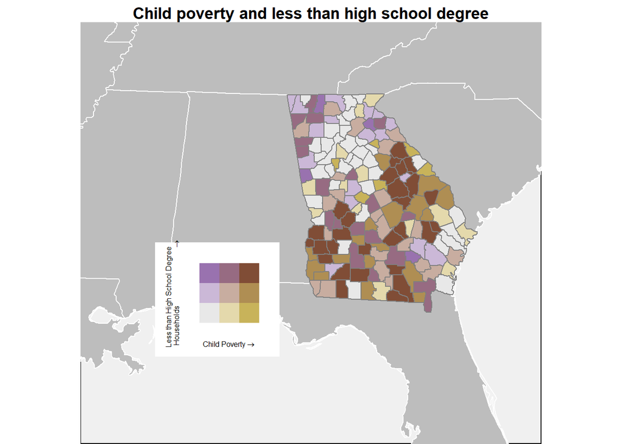

```r
unemploy_pov_map <- ggplot() +
  geom_polygon(data = world, aes(x=long,y=lat, group=group), fill = "gray95", color = "white") +
  geom_polygon(data = states, aes(x=long,y=lat, group=group), fill = "#bdbdbd", color = "white") +
  geom_polygon(data = southern_states, aes(x=long,y=lat, group=group), fill = NA, size = 0.01, color = "white") +
  geom_polygon(data = bivariate_data, aes(x=long, y=lat, group=group, fill = bi_class), color = "grey50", show.legend = FALSE) +
  bi_scale_fill(pal = "Brown", dim = 3) +
  coord_map("conic", lat0 = 30, xlim=c(-90,-80), ylim=c(28,36)) +
  theme_void() + theme(legend.title.align=0.5) +
  theme(panel.background = element_rect(fill = '#f0f0f0'),
        panel.grid.major = element_line(colour = NA)) +
  labs(x = "Longitude", y = "Latitude", fill = "Child Poverty",
       title = "Child poverty and less than high school degree") +
  theme(plot.title = element_text(face = "bold", hjust = 0.5))

final_map <- ggdraw() +
  draw_plot(unemploy_pov_map, 0, 0, 1, 1) +
  draw_plot(legend, 0.25, 0.15, 0.2, 0.35)

final_map
```